# Lab 2 - Team

Heather Moore and Ashley Sackpraseuth

9/13/2020

### Individual 1

## Reading the Data

```r
choco <- read.csv("https://raw.githubusercontent.com/xdaiISU/ds202materials/master/hwlabs/data/choco.csv")
str(choco)
```

```
## 'data.frame':    2312 obs. of  13 variables:
##  $ REF                 : int  2454 2458 2454 797 797 1015 1019 1011 1019 1011 ...
##  $ Company             : chr  "5150" "5150" "5150" "A. Morin" ...
##  $ Location            : chr  "U.S.A." "U.S.A." "U.S.A." "France" ...
##  $ Date                : int  2019 2019 2019 2012 2012 2013 2013 2013 2013 2013 ...
##  $ Bean_Origin         : chr  "Madagascar" "Dominican Republic" "Tanzania" "Peru" ...
##  $ Specific_Bean_Origin: chr  "Bejofo Estate, batch 1" "Zorzal, batch 1" "Kokoa Kamili, batch 1" "Peru" ...
##  $ Cocoa_Percent       : num  76 76 76 63 70 70 63 70 70 70 ...
##  $ Ingredients         : chr  "3- B,S,C" "3- B,S,C" "3- B,S,C" "4- B,S,C,L" ...
##  $ Characteristics1    : chr  "cocoa" "cocoa" "rich cocoa" "fruity" ...
##  $ Characteristics2    : chr  "blackberry" "vegetal" "fatty" "melon" ...
##  $ Characteristics3    : chr  "full body" "savory" "bready" "roasty" ...
##  $ Characteristics4    : chr  NA NA NA NA ...
##  $ Rating              : num  3.75 3.5 3.25 3.75 3.5 4 4 3.75 3.5 3.25 ...
```

### Searching for the Best Chocolates

1. How are the ratings distributed? Create both a histogram and a boxplot and describe them. Don’t forget to mention outliers, if there are any.

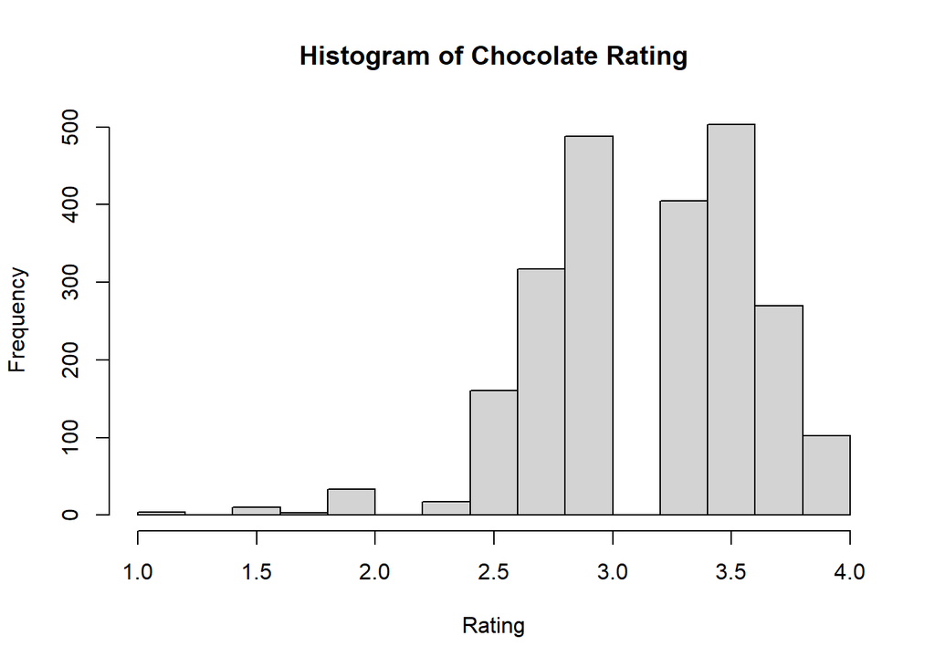

```r
hist(choco$Rating, main = 'Histogram of Chocolate Rating', xlab = "Rating")
```

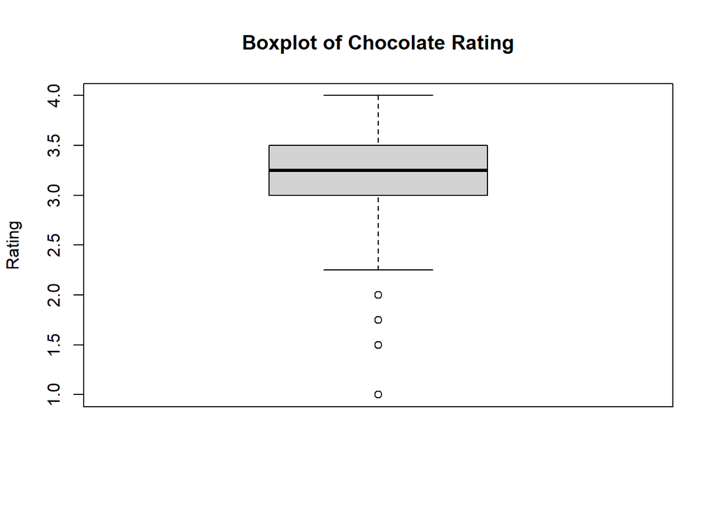

```r
boxplot(choco$Rating, main = 'Boxplot of Chocolate Rating', ylab = 'Rating')
```

The histogram shows that the ratings are skewed to the left, meaning many of the chocolates in this dataset received high ratings. The boxplot supports this because the IQR is relatively slim (most ratings fall between 3.0 and 3.5) and the median is approximately 3.25 - a high number considering the rating scale ranges from 1.0 to 4.0. There are four outliers as seen in the boxplot. They range on a scale from 1.0 to 2.0.

2. How does the number of ratings depend on the year? Draw a bar chart of the number of reports.

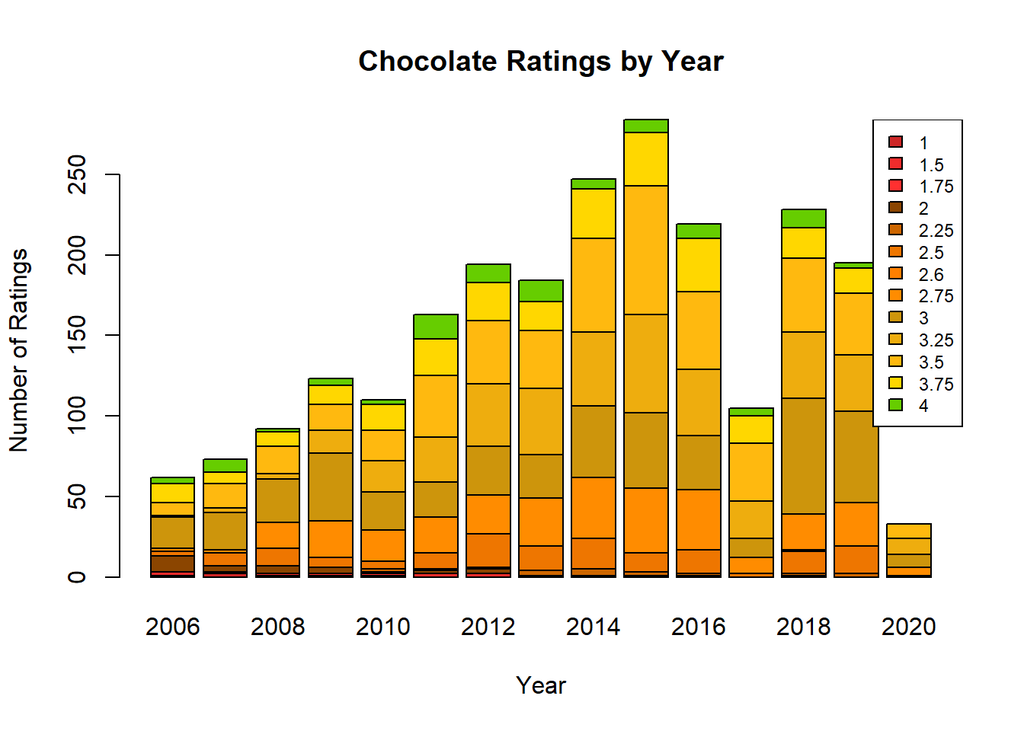

```r
choco_count <- table(choco$Rating, choco$Date)

rating_colors <- c("firebrick3", "firebrick2", "firebrick1", "darkorange4", "darkorange3", "darkorange2", "darkorange1", "darkorange", "darkgoldenrod3", "darkgoldenrod2", "darkgoldenrod1","gold", "chartreuse3")

barplot(choco_count, main = "Chocolate Ratings by Year", xlab = "Year", ylab = "Number of Ratings", col = rating_colors)

legend(x = "topright", cex = 0.75, fill = rating_colors, legend = c("1", "1.5", "1.75", "2", "2.25", "2.5", "2.6", "2.75", "3", "3.25", "3.5", "3.75", "4"))
```

3. Do ratings depend on the cacao percentage of a chocolate bar? Create both numerical and graphical summaries, and explain.

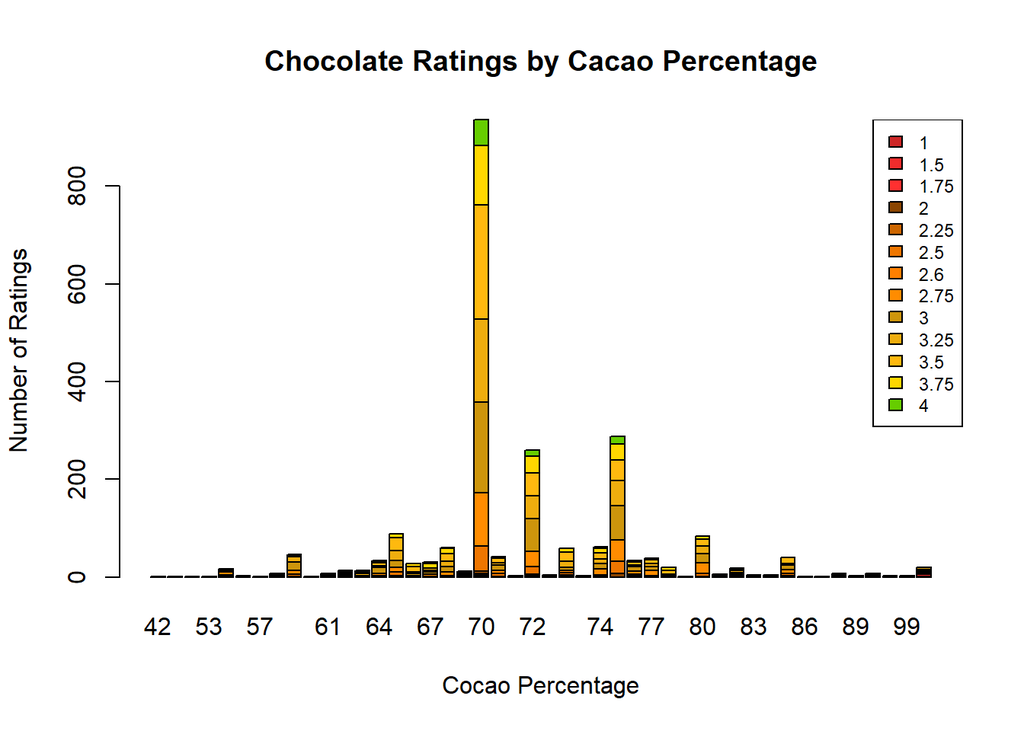

```r
cacao_count <- table(choco$Rating, choco$Cocoa_Percent)

rating_colors <- c("firebrick3", "firebrick2", "firebrick1", "darkorange4", "darkorange3", "darkorange2", "darkorange1", "darkorange", "darkgoldenrod3", "darkgoldenrod2", "darkgoldenrod1","gold", "chartreuse3")

barplot(cacao_count, main = "Chocolate Ratings by Cacao Percentage", xlab = "Cocao Percentage", ylab = "Number of Ratings", col = rating_colors)

legend(x = "topright", cex = 0.75, fill = rating_colors, legend = c("1", "1.5", "1.75", "2", "2.25", "2.5", "2.6", "2.75", "3", "3.25", "3.5", "3.75", "4"))
```

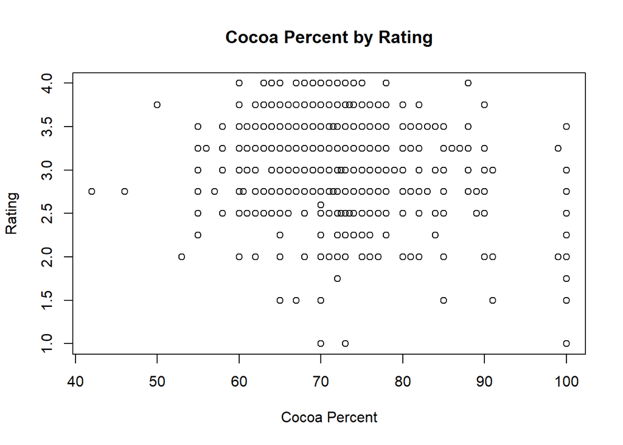

```r
plot(choco$Cocoa_Percent, choco$Rating, main = "Cocoa Percent by Rating", xlab = "Cocoa Percent", ylab = "Rating")
```

```r
Cocoa_Percent <- choco$Cocoa_Percent
Rating <- choco$Rating

choco_ranked <- head(choco[order(-Rating, Cocoa_Percent),], n = 10)
choco_ranked
```

```
##       REF             Company   Location Date Bean_Origin
## 104   572                AMMA     Brazil 2010      Brazil
## 7    1019            A. Morin     France 2013        Peru
## 1302  284 Madecasse (Cinagra) Madagascar 2008  Madagascar
## 2198 1510            Valrhona     France 2015        Peru
## 1964  676                Soma     Canada 2011        Peru
## 2183  129            Valrhona     France 2007  Madagascar
## 2193  757            Valrhona     France 2011   Venezuela
## 1872  336    Scharffen Berger     U.S.A. 2009       Ghana
## 1672 1034              Patric     U.S.A. 2013        Peru
## 1980 1081                Soma     Canada 2013       Blend
##                   Specific_Bean_Origin Cocoa_Percent  Ingredients
## 104  Monte Alegre, 3 diff. plantations            60   4- B,S,C,L
## 7                 Chanchamayo Province            63     3- B,S,C
## 1302                        Madagascar            63 5- B,S,C,V,L
```

[output cut: 18 more lines]

```r
choco_worst <- tail(choco[order(-Rating, Cocoa_Percent),], n = 10)
choco_worst
```

```
##      REF                 Company Location Date Bean_Origin
## 2189 147                Valrhona   France 2007       Blend
## 407  259 Cacaoyere (Ecuatoriana)  Ecuador 2008     Ecuador
## 284   81                  Bonnat   France 2006       Blend
## 308  341  Bouga Cacao (Tulicorp)  Ecuador 2009     Ecuador
## 573  817               Coppeneur  Germany 2012     Ecuador
## 1848 615                S.A.I.D.    Italy 2010       Blend
## 408  141               Callebaut  Belgium 2007     Ecuador
## 576   48      Cote d' Or (Kraft)  Belgium 2006       Blend
## 1542 135     Neuhaus (Callebaut)  Belgium 2007       Blend
## 544  252         Claudio Corallo Sao Tome 2008       Blend
##               Specific_Bean_Origin Cocoa_Percent  Ingredients
## 2189            Le Noir Extra Amer            85 5- B,S,C,V,L
## 407                      Pichincha            91   4- B,S,C,L
## 284                    One Hundred           100         <NA>
```

[output cut: 29 more lines]

4. How do different characteristics of the chocolate compare? To elaborate, which characteristics tend to be more favorable and which ones are not? Create both numerical and graphical summaries, and explain.

```r
choco_ranked
```

```
##       REF             Company   Location Date Bean_Origin
## 104   572                AMMA     Brazil 2010      Brazil
## 7    1019            A. Morin     France 2013        Peru
## 1302  284 Madecasse (Cinagra) Madagascar 2008  Madagascar
## 2198 1510            Valrhona     France 2015        Peru
## 1964  676                Soma     Canada 2011        Peru
## 2183  129            Valrhona     France 2007  Madagascar
## 2193  757            Valrhona     France 2011   Venezuela
## 1872  336    Scharffen Berger     U.S.A. 2009       Ghana
## 1672 1034              Patric     U.S.A. 2013        Peru
## 1980 1081                Soma     Canada 2013       Blend
##                   Specific_Bean_Origin Cocoa_Percent  Ingredients
## 104  Monte Alegre, 3 diff. plantations            60   4- B,S,C,L
## 7                 Chanchamayo Province            63     3- B,S,C
## 1302                        Madagascar            63 5- B,S,C,V,L
```

[output cut: 18 more lines]

```r
choco_worst
```

```
##      REF                 Company Location Date Bean_Origin
## 2189 147                Valrhona   France 2007       Blend
## 407  259 Cacaoyere (Ecuatoriana)  Ecuador 2008     Ecuador
## 284   81                  Bonnat   France 2006       Blend
## 308  341  Bouga Cacao (Tulicorp)  Ecuador 2009     Ecuador
## 573  817               Coppeneur  Germany 2012     Ecuador
## 1848 615                S.A.I.D.    Italy 2010       Blend
## 408  141               Callebaut  Belgium 2007     Ecuador
## 576   48      Cote d' Or (Kraft)  Belgium 2006       Blend
## 1542 135     Neuhaus (Callebaut)  Belgium 2007       Blend
## 544  252         Claudio Corallo Sao Tome 2008       Blend
##               Specific_Bean_Origin Cocoa_Percent  Ingredients
## 2189            Le Noir Extra Amer            85 5- B,S,C,V,L
## 407                      Pichincha            91   4- B,S,C,L
## 284                    One Hundred           100         <NA>
```

[output cut: 29 more lines]

5. Brainstorm two analyses you would like to perform with your teammate. Describe in plain language what comparisons are you making. Create suitable numerical and graphical summaries for your analyses. Describe the results.

One analysis I wanted to look at was chocolate ratings based on company to see which company makes the best chocolate. Another analysis I wanted to look was how the number of ingredients affects the rating.

```r
num_companies <- nlevels(choco$Company)
num_companies
```

```
## [1] 0
```

```r
comp_freq <- table(choco$Company)
View(comp_freq)
```

```r
#Rating Calculations
avg_soma <- mean(choco[choco$Company == "Soma", "Rating"], na.rm = TRUE)
avg_arete <- mean(choco[choco$Company == "Arete", "Rating"], na.rm = TRUE)
avg_fresco <- mean(choco[choco$Company == "Fresco", "Rating"], na.rm = TRUE)
avg_bonnat <- mean(choco[choco$Company == "Bonnat", "Rating"], na.rm = TRUE)
avg_pralus <- mean(choco[choco$Company == "Pralus", "Rating"], na.rm = TRUE)


#Ratings
avg_soma
```

```
## [1] 3.591346
```

```r
avg_arete
```

```
## [1] 3.53125
```

```r
avg_fresco
```

```
## [1] 3.403226
```

```r
avg_bonnat
```

```
## [1] 3.456897
```

```r
avg_pralus
```

```
## [1] 3.173077
```

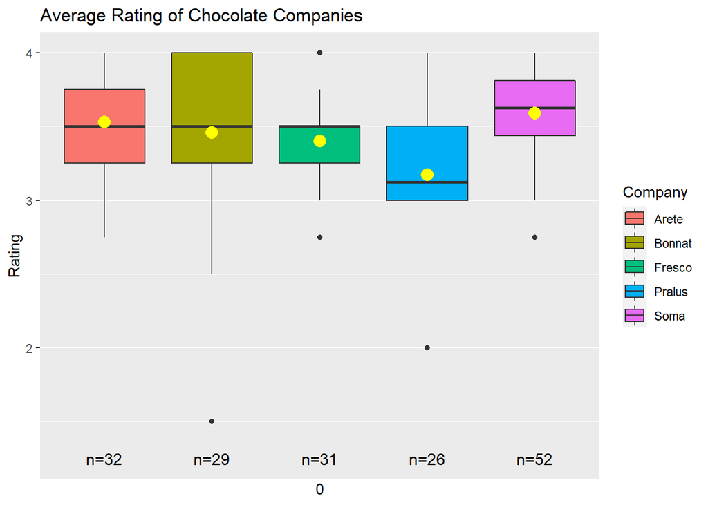

```r
#Boxplot
#(I am aware we haven't learned the following in class but I have prior R experience)

comp_df <- choco[(choco$Company == "Soma"| choco$Company == "Arete"| choco$Company == "Fresco"| choco$Company == "Bonnat"| choco$Company == "Pralus"),]


library(ggplot2)
library(EnvStats)
ggplot(comp_df, aes(`Company`,`Rating`, fill = `Company`))+ geom_boxplot() +
  ggtitle("Average Rating of Chocolate Companies") + labs(x="Company",y="Rating") + stat_n_text() +
  stat_summary(fun=mean, geom="point", shape=20, size=6, color="yellow", fill="yellow")+ scale_x_discrete(0, 45)
```

Soma has the best chocolate with an average rating of 3.59, followed by Arete with an average rating of 3.53, then Bonnat wtih 3.46, and lastly Pralus with 3.17. Based on the boxplot, Bonnat, Fresco, Pralus, and Soma all have their own outlier. Bonnat also appears to have the widest range of ratings.

To accomplish the next task, I made tables similar to choco_rank and choco_worst

```r
str(choco$Ingredients)
```

```
##  chr [1:2312] "3- B,S,C" "3- B,S,C" "3- B,S,C" "4- B,S,C,L" "4- B,S,C,L" ...
```

```r
Rating <- choco$Rating
Ingredients <- choco$Ingredients

ingred_best <- head(choco[order(-Rating, Ingredients),], n = 10)
ingred_best
```

```
##      REF         Company  Location Date     Bean_Origin
## 115 1598           Arete    U.S.A. 2015       Nicaragua
## 124 1908           Arete    U.S.A. 2016      Costa Rica
## 125 1924           Arete    U.S.A. 2016            Peru
## 137 2024           Arete    U.S.A. 2017         Bolivia
## 138 2028           Arete    U.S.A. 2017           Haiti
## 143 2254           Arete    U.S.A. 2018        Colombia
## 193 1295 Bar Au Chocolat    U.S.A. 2014            Peru
## 621  987           Danta Guatemala 2012       Guatemala
## 671 2016     Dick Taylor    U.S.A. 2017 Solomon Islands
## 675 2270     Dick Taylor    U.S.A. 2019          Belize
##                Specific_Bean_Origin Cocoa_Percent Ingredients Characteristics1
## 115                           Chuno            70      2- B,S           creamy
## 124           Coto Brus, Terciopelo            70      2- B,S         balanced
## 125                         Phantom            70      2- B,S           creamy
```

[output cut: 18 more lines]

```r
ingred_worst <- tail(choco[order(-Rating, Ingredients),], n = 10)
ingred_worst
```

```
##      REF                  Company Location Date Bean_Origin
## 2189 147                 Valrhona   France 2007       Blend
## 284   81                   Bonnat   France 2006       Blend
## 308  341   Bouga Cacao (Tulicorp)  Ecuador 2009     Ecuador
## 573  817                Coppeneur  Germany 2012     Ecuador
## 1299 721 Machu Picchu Trading Co.     Peru 2011        Peru
## 1848 615                 S.A.I.D.    Italy 2010       Blend
## 1542 135      Neuhaus (Callebaut)  Belgium 2007       Blend
## 408  141                Callebaut  Belgium 2007     Ecuador
## 544  252          Claudio Corallo Sao Tome 2008       Blend
## 576   48       Cote d' Or (Kraft)  Belgium 2006       Blend
##               Specific_Bean_Origin Cocoa_Percent  Ingredients
## 2189            Le Noir Extra Amer            85 5- B,S,C,V,L
## 284                    One Hundred           100         <NA>
## 308        El Oro, Hacienda de Oro           100         <NA>
```

[output cut: 29 more lines]

Based on the ingred_best table, the best tasting chocolates were made of 2 ingredients - beans and sugar. The worst tasting chocolates either had no information about their ingredients or were made up of 5 ingredients - beans, sugar, cocoa butter, vanilla, and lecithin. This finding makes sense because the more ingredients something has, the worst it is going to taste.